# NBA Scheduling Analysis

**A modeling experiment investigating league scheduling trends and evaluating fairness in scheduling difficulty across teams**

Bridget Muñoz

**Topics of Interest**

- How scheduling has shifted across the past decade
- Which features of a single game best predict the home or road team losing
- How many regular-season wins per team can be attributed to schedule luck rather than team quality

## Data Collection, Usage, and Transformation

- **Sample:** All regular-season game logs from the 13-14 season to the 25-26 season, pulled from `nba_api`.
- **Given variables:** date, team, matchup (opponent + home/away), and result — 4 raw columns from `LeagueGameLog`
- Each game arrives from `nba_api` as a handful of plain facts — the date, the two teams, who was home, and the result. These factors alone of course cannot holistically predict schedule difficulty, and the intention of this project is to display the ways only a few raw variables can be transformed into a well-formed analysis.

**This project turns 4 raw fields (date, team, matchup, result) into 9 engineered features, and predicts schedule difficulty using only those 9.**

| Category | Engineered features | # |
| --- | --- | --- |
| **Rest** | `rest_days`, `is_b2b`, `is_3in4`, `is_4in6` | 4 |
| **Travel** | `consecutive_away_games`, `days_since_home_game` | 2 |
| **Opponent quality** | `opp_prior_win_pct` | 1 |
| **Game context** | `is_away`, `is_nonconference` | 2 |

Every feature is derived from the schedule itself — no box-score or in-game stats leak in. The logistic SDS model consumes exactly these 9 columns and nothing else, so a game's predicted difficulty depends only on **rest, travel, opponent strength, and where it's played.**

```python
import warnings
warnings.filterwarnings('ignore')

import numpy as np
import pandas as pd
import matplotlib.pyplot as plt
import seaborn as sns

from data import load_schedule, DEFAULT_SEASONS
from model import (
    train_sds_model, score_sds, coefficient_table,
    schedule_driven_wins, ALL_FEATURES,
)

sns.set_theme(style='whitegrid', context='notebook')
plt.rcParams['figure.dpi'] = 100
plt.rcParams['font.family'] = 'serif'
plt.rcParams['font.serif'] = ['Times New Roman', 'Times', 'DejaVu Serif']

# the 4 raw fields per game
sched = load_schedule(DEFAULT_SEASONS)
```

```python
# turn the raw fields into the model features (same as features.py, just shown here)

def rolling_count_in_window(dates, window_days):
    # games in the last N days
    s = pd.Series(1, index=pd.DatetimeIndex(dates))
    return s.rolling(f"{window_days}D").sum().values.astype(int)


def add_rest(df):
    # rest: days off, b2b, 3-in-4, 4-in-6
    out = df.sort_values(["season", "team", "gamedate"]).copy()
    grp = out.groupby(["season", "team"], sort=False)
    out["rest_days"] = grp["gamedate"].diff().dt.days
    out["is_b2b"] = (out["rest_days"] == 1).astype(int)
    counts_6 = grp["gamedate"].transform(lambda s: rolling_count_in_window(s, 6))
    counts_4 = grp["gamedate"].transform(lambda s: rolling_count_in_window(s, 4))
    out["is_4in6"] = (counts_6 >= 4).astype(int)
    out["is_3in4"] = (counts_4 >= 3).astype(int)
    return out


def add_travel(df):
    # travel: road trip length, days since home
    out = df.copy()
    out["is_away"] = (1 - out["home"]).astype(int)
    out = out.sort_values(["season", "team", "gamedate"]).reset_index(drop=True)

    away = out["is_away"].values
    season_team = (out["season"].astype(str) + "|" + out["team"]).values
    trip = np.zeros(len(out), dtype=int)
    prev_key, run = None, 0
    for i in range(len(out)):
        if season_team[i] != prev_key:
            run, prev_key = 0, season_team[i]
        run = run + 1 if away[i] else 0
        trip[i] = run
    out["consecutive_away_games"] = trip

    days_away = np.zeros(len(out), dtype=int)
    last_home = {}
    for i in range(len(out)):
        key = season_team[i]
        if away[i] == 0:
            last_home[key] = out["gamedate"].iloc[i]
            days_away[i] = 0
        else:
            lh = last_home.get(key)
            days_away[i] = 0 if lh is None else (out["gamedate"].iloc[i] - lh).days
    out["days_since_home_game"] = days_away
    return out


def add_opp_prior_win_pct(df):
    # opponent's win pct going in
    out = df.sort_values(["season", "team", "gamedate"]).copy()
    grp = out.groupby(["season", "team"], sort=False)
    prior_wins = grp["win"].cumsum() - out["win"]
    prior_games = grp.cumcount()
    out["_prior_win_pct"] = np.where(prior_games > 0, prior_wins / prior_games, np.nan)
    lookup = out[["season", "team", "gamedate", "_prior_win_pct"]].rename(
        columns={"team": "opponent", "_prior_win_pct": "opp_prior_win_pct"}
    )
    merged = out.merge(lookup, on=["season", "opponent", "gamedate"], how="left")
    return (merged.drop(columns="_prior_win_pct")
                  .sort_values(["season", "team", "gamedate"])
                  .reset_index(drop=True))


def build_features(schedule):
    out = add_rest(schedule)
    out = add_travel(out)
    out = add_opp_prior_win_pct(out)
    out["is_nonconference"] = out["is_nonconf"]
    return out


feats = build_features(sched)
print(f'{len(feats):,} team-games across {feats["season"].nunique()} seasons')
print(f'4 raw fields -> {len(ALL_FEATURES)} engineered features:')
print(ALL_FEATURES)
```

```
31,338 team-games across 13 seasons
4 raw fields -> 9 engineered features:
['rest_days', 'consecutive_away_games', 'days_since_home_game', 'opp_prior_win_pct', 'is_b2b', 'is_3in4', 'is_4in6', 'is_away', 'is_nonconference']
```

## Section One: Scheduling Trends from 13-14 to 25-26 Seasons

The league office has publicly worked to reduce back-to-backs and 4-in-6 stretches over the past decade. The chart below tracks three per-season averages across team-seasons: share of games that are the second night of a back-to-back, share that fall inside a 4-in-6 stretch, and share that cross conferences.

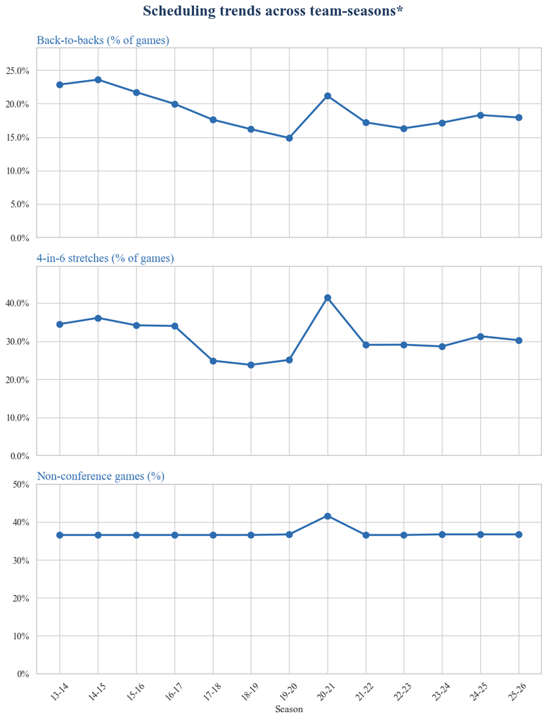

```python
from matplotlib.ticker import PercentFormatter

trend = (
    feats.groupby('season')[['is_b2b', 'is_4in6', 'is_nonconf']]
    .mean()
    .reset_index()
)
trend['season_short'] = trend['season'].str[2:]  # 2013-14 -> 13-14

# stacked so each panel is full width
fig, axes = plt.subplots(3, 1, figsize=(10, 13), sharex=True)
for ax, col, title in zip(
    axes,
    ['is_b2b', 'is_4in6', 'is_nonconf'],
    ['Back-to-backs (% of games)',
     '4-in-6 stretches (% of games)',
     'Non-conference games (%)'],
):
    ax.plot(trend['season_short'], trend[col], marker='o', linewidth=2.5,
            markersize=8, color='#2c6cb0')
    ax.set_title(title, fontsize=15, loc='left', color='#2c6cb0')
    ax.yaxis.set_major_formatter(PercentFormatter(xmax=1))
    ax.set_ylim(0, max(trend[col].max() * 1.2, 0.05))
    ax.tick_params(axis='both', labelsize=12)
axes[-1].set_xlabel('Season', fontsize=13)
axes[-1].tick_params(axis='x', rotation=45)
fig.suptitle('Scheduling trends across team-seasons*', y=0.995,
             fontsize=20, weight='bold', color='#1f3a5f')
plt.tight_layout()
plt.show()
```

* These charts measure the **percentage of all regular-season team-games, league-wide**, that fall into each category, by season. The dataset has one row per team per game, so every team is weighted equally (~82 games each). For example, "back-to-backs" is the share of team-games played on the second night of a back-to-back.

The downward drift in back-to-backs and 4-in-6 stretches is consistent with the league's stated scheduling goals. The non-conference share is roughly stable, holding near the long-run mix. Additionally, one can see how the COVID season impacted scheduling in these charts. Non-conference share is consistent besides the bubble. The proportion of 4-in-6 and back-to-back stretches seem to have a linear relationship, both steadily decreasing until the COVID season, sharp increase, then staying stagnant in following seasons.

## Section Two: W/L Prediction for a Given Team Based on Scheduling Factors

The schedule-difficulty score (SDS) is a logistic regression fit to one row per team-game. The model's target is to predict whether a given team wins or loses a given game based on scheduling factors. Each factor is learned from existing game results — the model measures how the makeup of these variables within a game changes the outcome. For example, playing a back-to-back (when the B2B variable flips from 0 to 1) raises a team's odds of losing that game by about 24%. Features and their impacts are listed below.

```python
train_seasons = DEFAULT_SEASONS[:-1]
score_season = DEFAULT_SEASONS[-1]

model = train_sds_model(feats, train_seasons)
scored = score_sds(model, feats[feats['season'] == score_season])

coefs = coefficient_table(model)
coefs.style.format({'coef': '{:.3f}', 'odds_ratio': '{:.2f}'}).background_gradient(
    subset=['coef'], cmap='RdBu_r', vmin=-0.7, vmax=0.7
)
```

|  | feature | coef | odds_ratio |
| --- | --- | --- | --- |
| 0 | is_away | 0.592 | 1.81 |
| 1 | opp_prior_win_pct | 0.449 | 1.57 |
| 2 | is_b2b | 0.214 | 1.24 |
| 3 | consecutive_away_games | -0.026 | 0.97 |
| 4 | is_3in4 | 0.020 | 1.02 |
| 5 | is_nonconference | 0.010 | 1.01 |
| 6 | rest_days | -0.009 | 0.99 |
| 7 | is_4in6 | 0.008 | 1.01 |
| 8 | days_since_home_game | 0.002 | 1.00 |

**Reading the coefficients:** Unsurprisingly, playing on the road is the largest single contributor to losing a given game, followed by facing a stronger opponent. The model implies that a team on the road already faces roughly 44/56 odds against the home team. A few of the factors I studied have a slight *positive* impact on win probability. Interestingly, every added consecutive away game nudges the win% upward. I'd speculate that the first away game carries the highest loss probability, and that each additional game away lets the team adjust to the time-zone or environment change.

### Calendar heatmap of game difficulty

This chart is a calendar that fills in each game day with a color and its predicted loss probability — greener days are easier games, redder days are harder. I chose SAC and HOU for the 25-26 season as they had the most difficult and easiest predicted schedules, respectively.

```
Hardest 2025-26 schedule (avg SDS): SAC (0.520)
Easiest 2025-26 schedule (avg SDS): HOU (0.481)
```

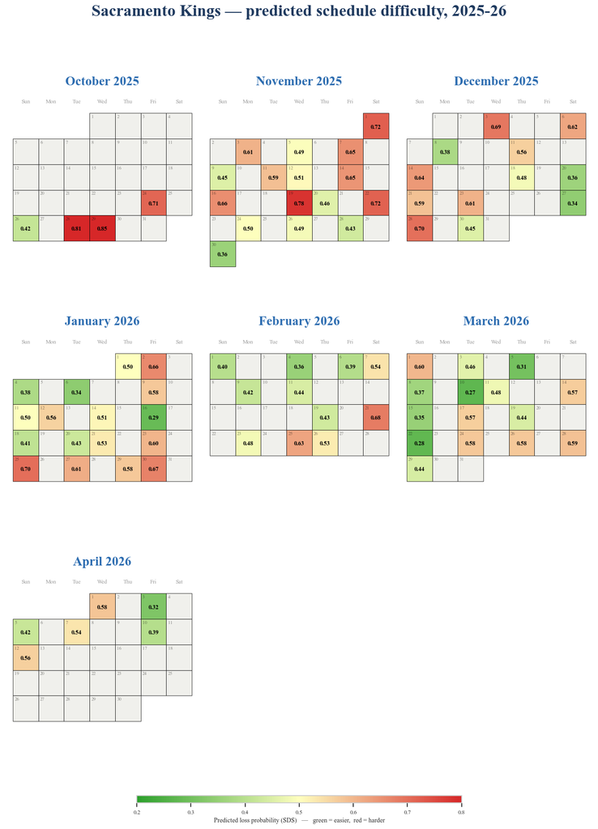

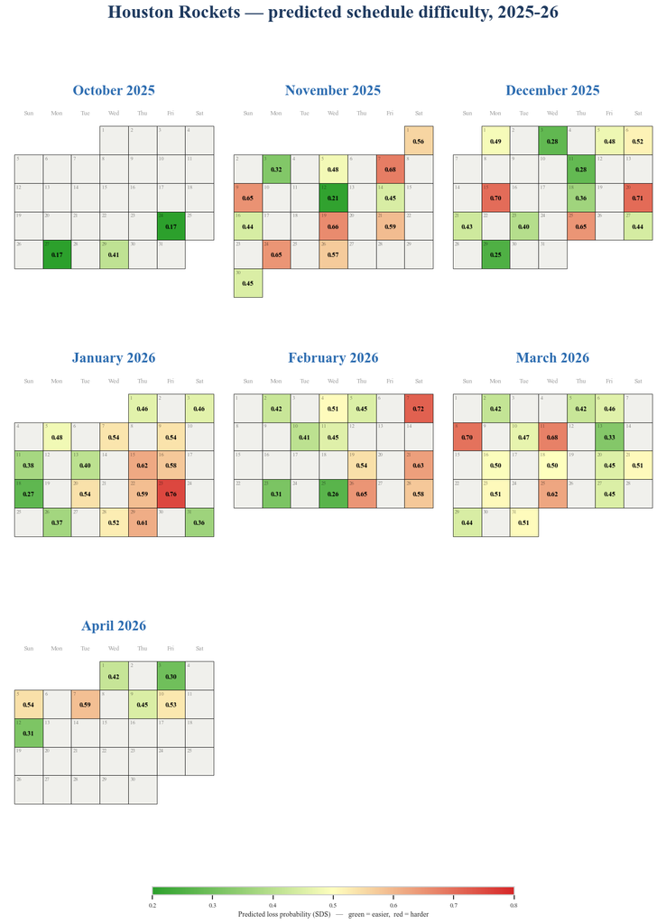

```python
import calendar
import datetime
from matplotlib.colors import LinearSegmentedColormap, Normalize
from matplotlib.patches import Rectangle

calendar.setfirstweekday(calendar.SUNDAY)
WEEKDAYS = ['Sun', 'Mon', 'Tue', 'Wed', 'Thu', 'Fri', 'Sat']

SDS_CMAP = LinearSegmentedColormap.from_list('sds', ['#2ca02c', '#ffffbf', '#d62728'])

TEAM_NAMES = {
    'ATL': 'Atlanta Hawks', 'BOS': 'Boston Celtics', 'BKN': 'Brooklyn Nets',
    'CHA': 'Charlotte Hornets', 'CHI': 'Chicago Bulls', 'CLE': 'Cleveland Cavaliers',
    'DAL': 'Dallas Mavericks', 'DEN': 'Denver Nuggets', 'DET': 'Detroit Pistons',
    'GSW': 'Golden State Warriors', 'HOU': 'Houston Rockets', 'IND': 'Indiana Pacers',
    'LAC': 'LA Clippers', 'LAL': 'Los Angeles Lakers', 'MEM': 'Memphis Grizzlies',
    'MIA': 'Miami Heat', 'MIL': 'Milwaukee Bucks', 'MIN': 'Minnesota Timberwolves',
    'NOP': 'New Orleans Pelicans', 'NOH': 'New Orleans Hornets', 'NYK': 'New York Knicks',
    'OKC': 'Oklahoma City Thunder', 'ORL': 'Orlando Magic', 'PHI': 'Philadelphia 76ers',
    'PHX': 'Phoenix Suns', 'POR': 'Portland Trail Blazers', 'SAC': 'Sacramento Kings',
    'SAS': 'San Antonio Spurs', 'TOR': 'Toronto Raptors', 'UTA': 'Utah Jazz',
    'WAS': 'Washington Wizards',
}


def calendar_heatmap(team_scored, team_label, months_per_row=3):
    # one little calendar per month, each game day colored by its SDS
    df = team_scored.dropna(subset=['SDS']).copy()
    sds_by_date = {d.date(): s for d, s in zip(df['gamedate'], df['SDS'])}
    periods = sorted({(d.year, d.month) for d in df['gamedate']})

    GX, GY = 0.7, 1.4           # gaps between month blocks
    BW, BH = 7, 8               # 7 weekday cols; 1 title + 1 header + 6 week rows
    n_block_rows = -(-len(periods) // months_per_row)   # ceil
    total_w = months_per_row * (BW + GX) - GX
    total_h = n_block_rows * (BH + GY)

    norm = Normalize(vmin=0.2, vmax=0.8)
    fig, ax = plt.subplots(figsize=(total_w * 0.58, total_h * 0.58))

    for i, (yr, mo) in enumerate(periods):
        bc, br = i % months_per_row, i // months_per_row
        x0 = bc * (BW + GX)
        y0 = -br * (BH + GY)           # top of this month block

        ax.text(x0 + BW / 2, y0 - 0.6, calendar.month_name[mo] + f' {yr}', fontsize=18,
                weight='bold', ha='center', va='bottom', color='#2c6cb0')
        for c, wd in enumerate(WEEKDAYS):
            ax.text(x0 + c + 0.5, y0 - 1.15, wd, ha='center', va='center',
                    fontsize=8, color='#999')

        for w, week in enumerate(calendar.monthcalendar(yr, mo)):
            top = y0 - 1.6 - w         # top edge of this week's cells
            for c, day in enumerate(week):
                if day == 0:
                    continue
                cx = x0 + c
                sds = sds_by_date.get(datetime.date(yr, mo, day))
                face = SDS_CMAP(norm(sds)) if sds is not None else '#f0f0ec'
                ax.add_patch(Rectangle((cx, top - 1), 1, 1, facecolor=face,
                                       edgecolor='black', linewidth=0.5, zorder=0))
                ax.text(cx + 0.07, top - 0.07, str(day), ha='left', va='top',
                        fontsize=6.5, color=(0, 0, 0, 0.45), zorder=1)
                if sds is not None:
                    ax.text(cx + 0.5, top - 0.55, f'{sds:.2f}', ha='center', va='center',
                            fontsize=8.5, weight='bold', color='black', zorder=2)

    ax.set_xlim(-0.3, total_w + 0.3)
    ax.set_ylim(-total_h + 0.5, 1.6)
    ax.set_aspect('equal')
    ax.axis('off')
    full_name = TEAM_NAMES.get(team_label, team_label)
    ax.set_title(f'{full_name} — predicted schedule difficulty, {score_season}',
                 fontsize=23, weight='bold', loc='center', color='#1f3a5f', pad=22)

    sm = plt.cm.ScalarMappable(norm=norm, cmap=SDS_CMAP)
    cbar = fig.colorbar(sm, ax=ax, orientation='horizontal', fraction=0.03,
                        pad=0.02, aspect=45, shrink=0.5)
    cbar.set_label('Predicted loss probability (SDS)   —   green = easier,  red = harder',
                   fontsize=9)
    cbar.ax.tick_params(labelsize=8)
    return ax


team_avg_sds = scored.groupby('team')['SDS'].mean().sort_values()
easiest_team = team_avg_sds.index[0]
hardest_team = team_avg_sds.index[-1]
print(f'Hardest {score_season} schedule (avg SDS): {hardest_team} ({team_avg_sds[hardest_team]:.3f})')
print(f'Easiest {score_season} schedule (avg SDS): {easiest_team} ({team_avg_sds[easiest_team]:.3f})')

for team_label in [hardest_team, easiest_team]:
    calendar_heatmap(scored[scored['team'] == team_label], team_label)
    plt.tight_layout()
    plt.show()
```

The two calendars above show how scheduling difficulty actually plays out in practice. The team with the highest average SDS faces a schedule with more road games, back-to-backs, and stronger opponents; the team with the lowest average SDS gets the opposite. Note that even the toughest team's typical game still hovers around a 50% loss probability, since opponent strength dominates inside any single matchup. The schedule moves the dial at the margins. In a league of the best basketball players in the world competing against and amongst each other, the margin can often be the deciding factor. Additionally, one must consider that these athletes are used to constant travel for games, often since middle or high school. That said, sometimes the numbers line up. During one of their toughest weeks of the season according to the model (1/25 to 1/30), SAC lost all four away games that the heatmap predicted they would lose. Overall, however, it is important to remember that this level of travel is familiar to most athletes, and they are expected to perform at their skill level whether they are home or away.

## Section Three: Wins Above or Below Schedule Expectation

Interestingly, if two teams with comparable roster skill and makeup play two different schedules, their paths to the same record might also look quite different. This chart tries to estimate how many wins each team's schedule may have added or cost them over a season, rather than how good the team itself is. It does this by holding opponent quality constant and replacing each team's schedule features (number of back-to-back games, non-conference scheduling, etc.) with the league average. In theory, this strips out some of the noise in game results that comes from a team drawing a tougher or easier schedule, leaving a rough sense of how many wins might be attributable to the schedule itself rather than to things like jetlag. The difference between expected wins under the actual schedule and expected wins under the neutral schedule is what I'm calling the team's *schedule-driven wins* for that season.

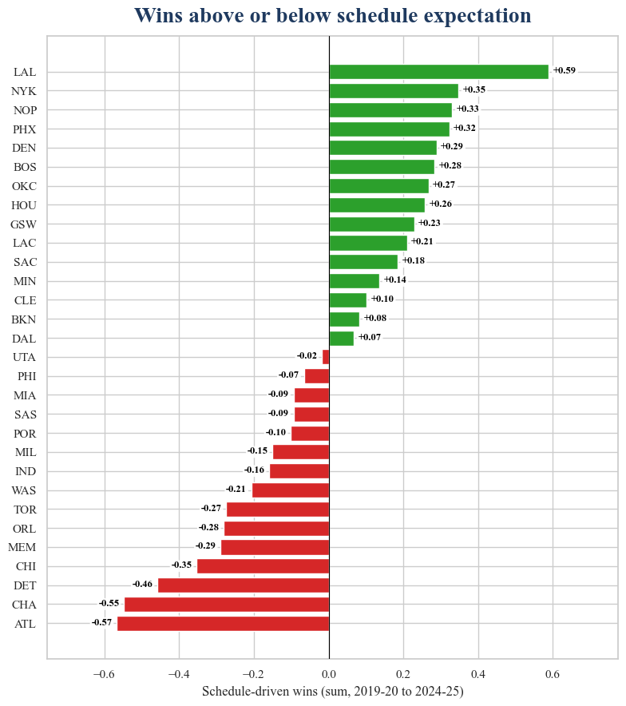

```python
window = [s for s in DEFAULT_SEASONS if s >= '2019-20']
sched_wins = schedule_driven_wins(model, feats, window)
team_totals = (
    sched_wins.groupby('team')['schedule_wins']
    .sum()
    .sort_values()
)

fig, ax = plt.subplots(figsize=(8, 9))
ax.set_axisbelow(True)               # gridlines behind the bars
colors = ['#2ca02c' if v > 0 else '#d62728' for v in team_totals.values]
bars = ax.barh(team_totals.index, team_totals.values, color=colors, zorder=3)
ax.axvline(0, color='black', linewidth=0.8, zorder=4)

# white box behind the numbers so the gridlines don't cut through
labels = ax.bar_label(bars, labels=[f'{v:+.2f}' for v in team_totals.values],
                      padding=4, fontsize=9, fontweight='bold', color='black')
for t in labels:
    t.set_zorder(6)
    t.set_bbox(dict(boxstyle='round,pad=0.15', facecolor='white',
                    edgecolor='none', alpha=0.9))

ax.margins(x=0.16)                    # room so labels don't clip
ax.set_xlabel('Schedule-driven wins (sum, 2019-20 to 2024-25)')
ax.set_title('Wins above or below schedule expectation', loc='center',
             fontsize=20, weight='bold', color='#1f3a5f', pad=12)
plt.tight_layout()
plt.show()
```

## Section Four: Comparing Scheduling Factors Across Teams

The chart below lets you switch between different per-team metrics for the 2025-26 season. No matter which metric you pick, the teams stay in the same order (sorted by their average SDS, the model's predicted schedule difficulty), so you can eyeball whether the patterns seem to line up. I found that this gave similar results to the rest of the tests: any difference is minuscule. The NBA schedule is designed to be roughly equally convenient (or inconvenient) for all teams; you can see that each team ends up with roughly the same average number of rest days, purely due to the limits of an 82-game season in eight months, and I would assume partly because of broadcasting and arena considerations. That said, looking at these graphs helped me understand just how small of an influence scheduling seems to have on winning games.

Metric:

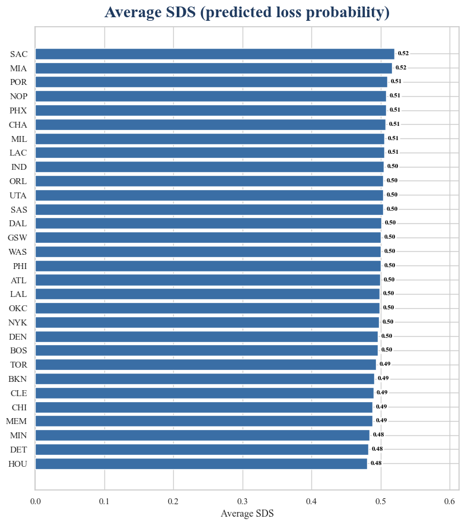

```python
import io, base64
from IPython.display import HTML, display
from matplotlib.ticker import PercentFormatter

# per-team metrics for the latest season
season_df = feats[feats['season'] == score_season]
sched_wins_season = (
    schedule_driven_wins(model, feats, [score_season]).set_index('team')['schedule_wins']
)

# keep teams in the same order (by SDS) for every metric
order = scored.groupby('team')['SDS'].mean().sort_values().index   # hardest at top

metrics = [
    ('Average SDS (predicted loss probability)', scored.groupby('team')['SDS'].mean(),       'Average SDS',            'dec'),
    ('Win percentage',                            season_df.groupby('team')['win'].mean(),    'Win percentage',         'pct'),
    ('Back-to-backs (% of games)',                season_df.groupby('team')['is_b2b'].mean(), 'Share of games',         'pct'),
    ('4-in-6 stretches (% of games)',             season_df.groupby('team')['is_4in6'].mean(),'Share of games',         'pct'),
    ('Non-conference games (% of games)',         season_df.groupby('team')['is_nonconf'].mean(), 'Share of games',     'pct'),
    ('Average rest days between games',           season_df.groupby('team')['rest_days'].mean(),  'Average rest days',  'dec'),
    ('Schedule-driven wins',                      sched_wins_season,                          'Schedule-driven wins',   'signed'),
]


def render(series, title, xlabel, kind):
    s = series.reindex(order)
    fig, ax = plt.subplots(figsize=(8, 9))
    ax.set_axisbelow(True)
    if kind == 'signed':
        colors = ['#2ca02c' if v > 0 else '#d62728' for v in s.values]
    else:
        colors = '#3a6ea5'
    bars = ax.barh(s.index, s.values, color=colors, zorder=3)
    if kind == 'signed':
        ax.axvline(0, color='black', linewidth=0.8, zorder=4)
        fmt = lambda v: f'{v:+.2f}'
    elif kind == 'pct':
        ax.xaxis.set_major_formatter(PercentFormatter(xmax=1))
        fmt = lambda v: f'{v * 100:.1f}%'
    else:
        fmt = lambda v: f'{v:.2f}'
    lbls = ax.bar_label(bars, labels=[fmt(v) for v in s.values],
                        padding=4, fontsize=8, fontweight='bold', color='black')
    for t in lbls:
        t.set_zorder(6)
        t.set_bbox(dict(boxstyle='round,pad=0.15', facecolor='white', edgecolor='none', alpha=0.9))
    ax.margins(x=0.18)
    ax.set_xlabel(xlabel)
    ax.set_title(title, loc='center', fontsize=20, weight='bold', color='#1f3a5f', pad=12)
    plt.tight_layout()
    buf = io.BytesIO()
    fig.savefig(buf, format='png', dpi=100, bbox_inches='tight')
    plt.close(fig)
    return base64.b64encode(buf.getvalue()).decode('ascii')


rendered = [(label, render(series, label, xlab, kind)) for (label, series, xlab, kind) in metrics]

opts = '\n'.join(f'<option value="se4-m{i}">{label}</option>' for i, (label, _) in enumerate(rendered))
imgtags = '\n'.join(
    f'<img id="se4-m{i}" src="data:…" '
    f'style="max-width:100%;height:auto;display:{"block" if i == 0 else "none"};margin:0 auto;">'
    for i, (label, b64) in enumerate(rendered)
)
onchange = ("var box=this.closest('.metric-explorer').querySelector('.metric-imgs');"
            "box.querySelectorAll('img').forEach(function(im){im.style.display='none';});"
            "document.getElementById(this.value).style.display='block';")

html = f"""<div class="metric-explorer">
  <label class="metric-pick">Metric:&nbsp;<select onchange="{onchange}">
  {opts}
  </select></label>
  <div class="metric-imgs">
  {imgtags}
  </div>
</div>"""
display(HTML(html))
```

## Notes

- All game logs and schedules are from `nba_api.stats.endpoints.LeagueGameLog`, regular season only, 2013-14 through the most recent season. Graphs and models will automatically update upon completion of the 26-27 season.
- The SDS model uses logistic regression with standardized numeric features. Features and target definitions live in `features.py` and `model.py`.
- The schedule-driven wins visual standardizes opponent prior win percentage and replaces schedule features with their league average. This treats schedule fairness as the variable of interest while keeping who plays whom standardized.

Built with Python, pandas, scikit-learn, matplotlib, and seaborn.  
Schedule and game-log data via nba_api.  
[View the source code on GitHub →](https://github.com/bridgetmunoz23/schedule_python)